# Toy Horse Case Assignment

Yanzi Cai, Ao Zhang, Sizhu Wu, Dong Li, Keyan Wang

### Project Background

- Conjoint analysis for toy horse company EarlyRiders.
- Dataset
  - “conjointData” (ratings of different profiles, which refer to different attributes, provided by 200 individuals.Missing value included.)
  - “profilesData” (16 total profiles,attributes include price(119.99 and 139.99), size(18 and 26 inches), motion(Bouncing and Rocking), style(Racing and Glamour))
  - “repondentData” (age and gender of 200 respondents)
- Current products
  - EarlyRiders: 18’‘Glamorous Rocking Horse and 18’’ Racing Rocking Horse, both at $139.99 (profile 13 and profile 5)
  - Competitor: 26’’ Racing Rocking Horse at $139.99
- Mandate
  - Understanding market preferences in order to reviralize broader product line.
  - Taking advantage of differences across people to target new products or modify existing products to better target segments.

### Analysis task

##### A. Use Regression to estimate the conjoint model at the individual level.

##### B. Conduct Benefit Segmentation via Cluster Analysis of Conjoint Part-Utilities.

##### C. Conduct a priori segmentation.

##### D. Simulate market shares for different product-line scenarios.

##### Set up

```r
library(cluster)
library(fpc)
library(factoextra)
library(gridExtra)
library(splus2R)

#load data
load("GBA424 - Toy Horse Case Data.Rdata")
conjointDataReg = conjointData[is.na(conjointData$ratings)==FALSE,]
```

##### Part A Conjoint Analysis:

- Produce part-utilities to pass to part B.
- Produce predictions for missing profiles to pass to part D.

```r
#individual coefficients & profile prediction
conjointDataReg = conjointDataReg[,-2]
indiData = as.data.frame(matrix(NA,200,6))
colnames(indiData) = c("id","(intercept)","priceLow","sizeLarge","motionRocking","styleGlamour")
for (id in 1:200){
  data = conjointDataReg[conjointDataReg$ID == id,]
  lm = summary(lm(ratings~price+size+motion+style,data = data))
  indiData[id,1] = id
  indiData[id,2] = lm[[4]][1]
  indiData[id,3] = lm[[4]][2]
  indiData[id,4] = lm[[4]][3]
  indiData[id,5] = lm[[4]][4]
  indiData[id,6] = lm[[4]][5]
  lm = lm(ratings~price+size+motion+style,data = data)
  conjointData[conjointData$ID == id&is.na(conjointData$ratings),3] = predict(lm,conjointData[conjointData$ID == id& is.na(conjointData$ratings),3:7])
}
############### PART A ###############
```

##### Part B Cluster Analysis:

- Use cluster analysis on the part-utilities.
- Test multiple cluster analysis schemes(i.e.,number of clusters) and select the best one.
- Interprete the segments in the chosen scheme and identify the ideal product for each segment.

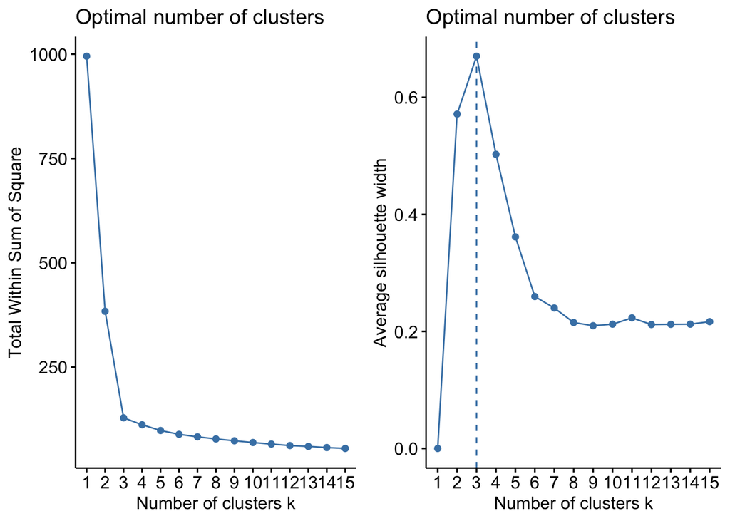

```
## $wss
##  [1] 995.00000 383.84977 128.60229 111.91819  98.14994  88.99271  82.89681
##  [8]  77.15171  73.46641  68.69521  64.82040  61.51011  59.94983  56.69644
## [15]  55.22111
##
## $pm1
## [1] 3
##
## $gpw
```

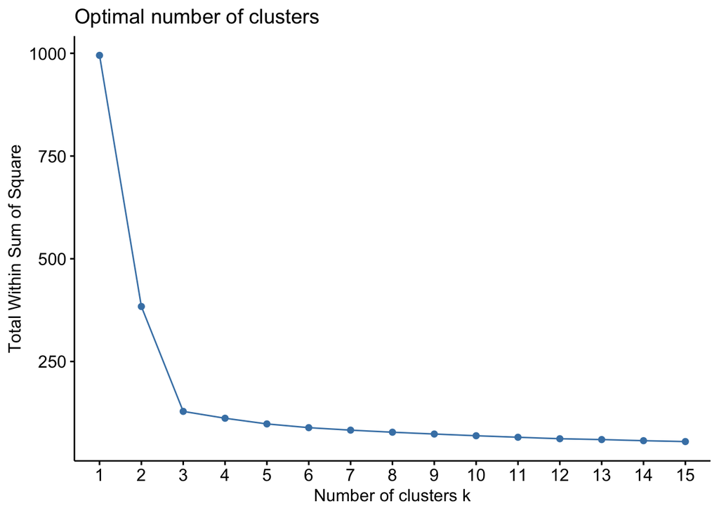

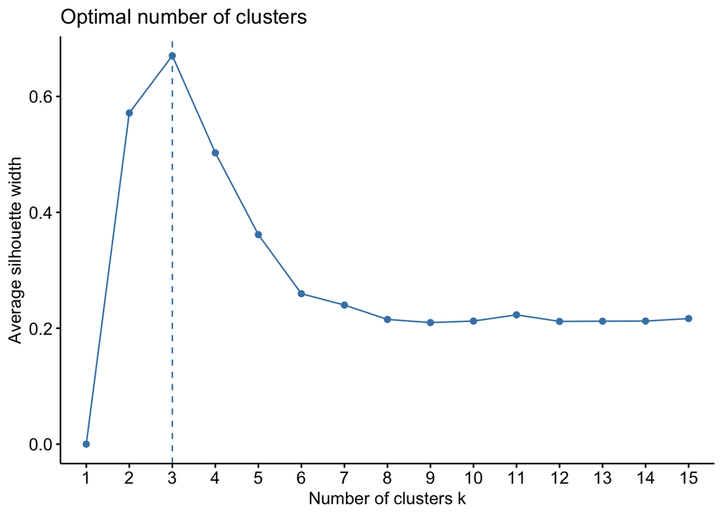

```r
############### PART B ###############
indiDataNew = indiData[,-1]
clustTest = function(toClust,print=TRUE,scale=TRUE,maxClusts=15,seed=12345,nstart=20,iter.max=100){
  if(scale){ toClust = scale(toClust);}
  set.seed(seed)
  wss <- (nrow(toClust)-1)*sum(apply(toClust,2,var))
  for (i in 2:maxClusts) wss[i] <- sum(kmeans(toClust,centers=i,nstart=nstart,iter.max=iter.max)$withinss)
  gpw = fviz_nbclust(toClust,kmeans,method="wss",iter.max=iter.max,nstart=nstart,k.max=maxClusts)
  pm1 = pamk(toClust,scaling=TRUE)
  gps = fviz_nbclust(toClust,kmeans,method="silhouette",iter.max=iter.max,nstart=nstart,k.max=maxClusts)
  if(print){
    grid.arrange(gpw,gps, nrow = 1)
  }
  list(wss=wss,pm1=pm1$nc,gpw=gpw,gps=gps)
}
clustTest(indiDataNew)
```

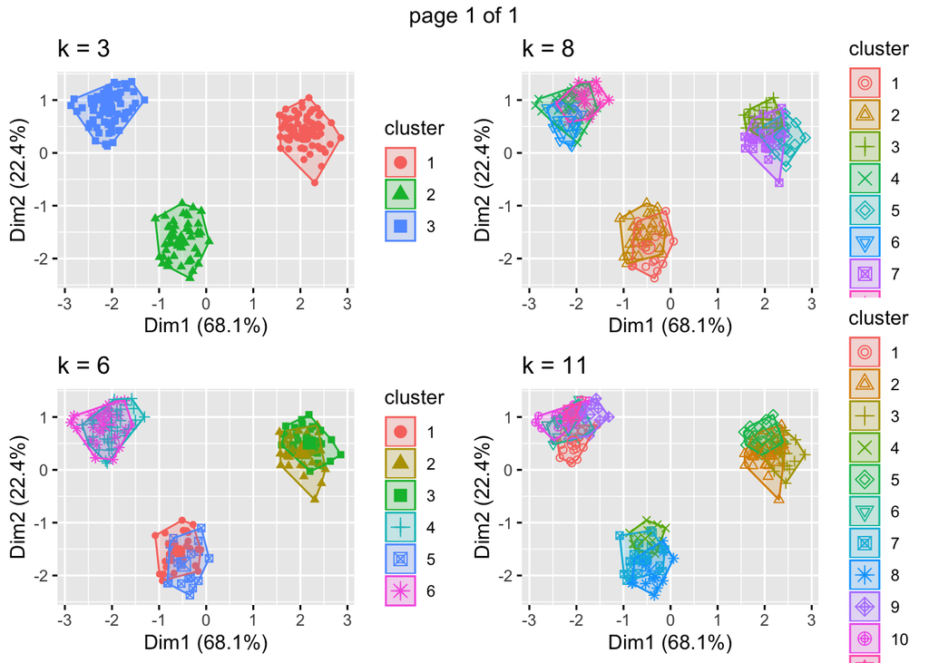

```
## $kms
## $kms[[1]]
## K-means clustering with 3 clusters of sizes 80, 53, 67
##
## Cluster means:
##   (intercept)  priceLow sizeLarge motionRocking styleGlamour
## 1    31.50291 22.474947  5.348628     -9.434120   -6.6285255
## 2    40.88116 11.564861 -6.561319     10.038882    0.4726337
## 3    46.13706  8.938311 16.593109      6.965209   10.9539010
##
## Clustering vector:
##   [1] 3 2 3 3 1 2 3 1 1 1 1 2 3 2 1 2 2 1 3 3 3 3 3 1 1 1 3 2 3 3 2 3 2 1 1
##  [36] 3 1 3 1 3 2 2 3 1 1 3 3 1 3 3 2 2 1 1 3 1 3 2 3 2 2 3 1 1 2 3 3 1 3 1
##  [71] 2 2 1 2 1 2 3 3 1 1 3 3 1 2 3 3 3 2 2 1 1 2 1 2 1 2 1 3 1 1 3 3 2 3 2
## [106] 1 1 1 1 2 2 1 2 1 1 3 2 1 1 2 1 1 3 1 1 3 2 1 3 3 3 1 1 3 3 1 3 1 1 2
## [141] 1 1 3 3 1 1 1 1 3 2 3 2 1 1 3 1 3 1 3 3 3 2 2 1 1 2 2 2 3 3 3 2 3 1 3
## [176] 1 2 1 1 2 2 1 1 1 1 2 2 2 2 3 1 1 3 2 3 1 1 1 2 3
##
## Within cluster sum of squares by cluster:
## [1] 2877.538 2175.215 2900.584
##  (between_SS / total_SS =  88.0 %)
##
## Available components:
##
## [1] "cluster"      "centers"      "totss"        "withinss"
## [5] "tot.withinss" "betweenss"    "size"         "iter"
## [9] "ifault"
##
## $kms[[2]]
## K-means clustering with 6 clusters of sizes 28, 45, 35, 37, 25, 30
##
## Cluster means:
##   (intercept)  priceLow sizeLarge motionRocking styleGlamour
## 1    42.55563 10.636412 -6.129407      7.571678   0.04927482
## 2    33.66315 21.626847  4.639134    -10.480469  -7.99680769
## 3    28.72547 23.565362  6.260833     -8.088815  -4.86930561
## 4    44.10202 10.034537 16.458105      8.572010  12.20922591
## 5    39.00576 12.604724 -7.045059     12.802150   0.94679567
## 6    48.64693  7.586299 16.759615      4.983488   9.40566692
##
```

[output cut: 77 more lines]

```
##
## Within cluster sum of squares by cluster:
##  [1] 369.69554 740.63472 426.43374 241.07260 435.35211 305.03940 541.44037
##  [8] 521.46297 302.85357 286.95009  73.70424
##  (between_SS / total_SS =  93.6 %)
##
## Available components:
##
## [1] "cluster"      "centers"      "totss"        "withinss"
## [5] "tot.withinss" "betweenss"    "size"         "iter"
## [9] "ifault"
##
##
## $ps
## $ps[[1]]
```

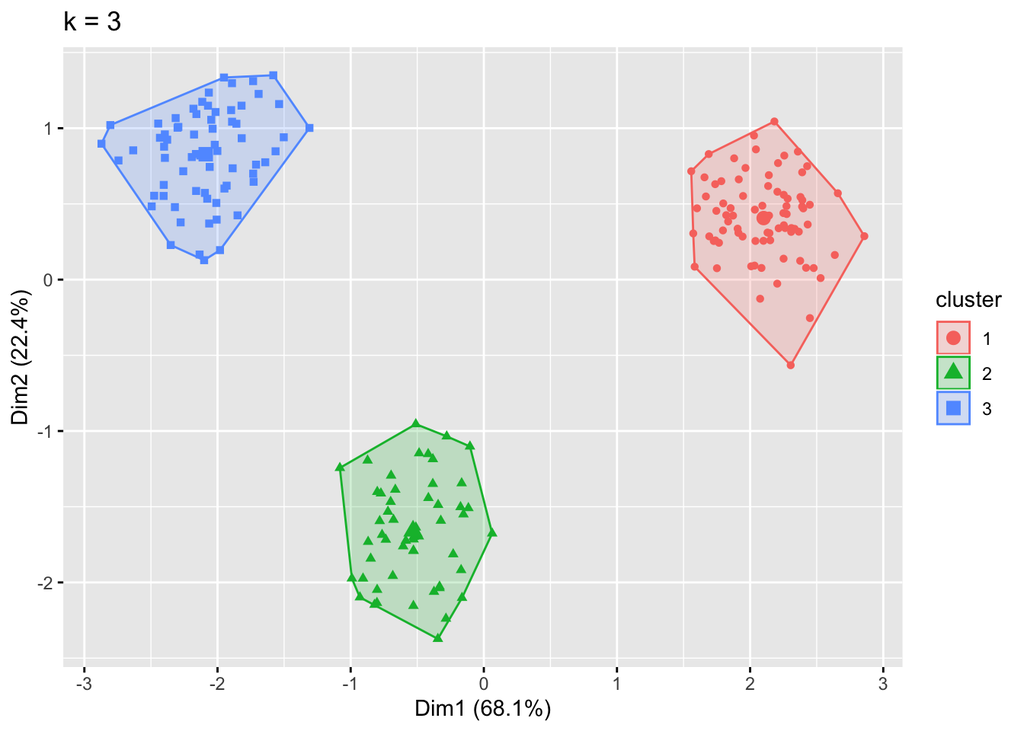

```
##
## $ps[[2]]
```

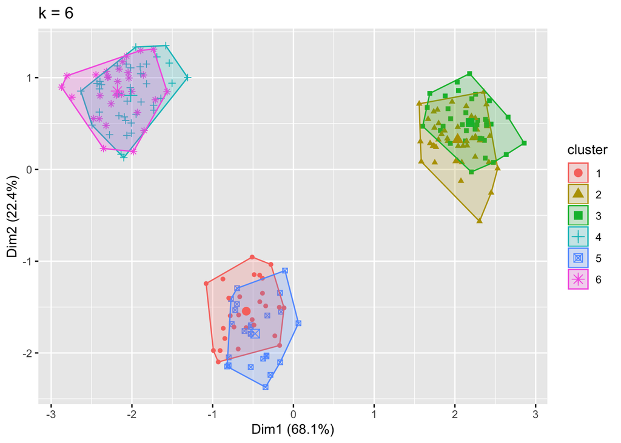

```
##
## $ps[[3]]
```

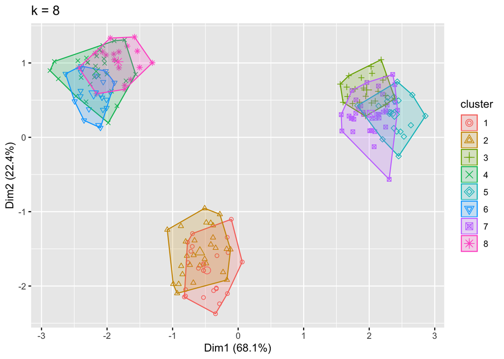

```
##
## $ps[[4]]
```

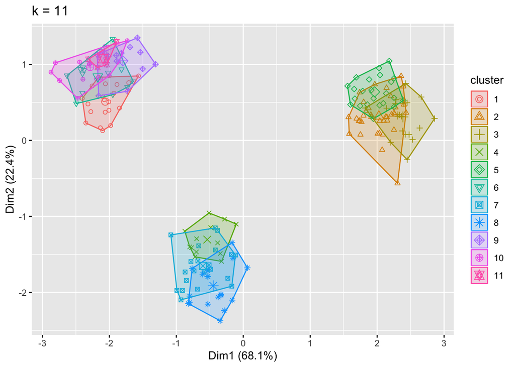

```r
runClusts = function(toClust,nClusts,print=TRUE,maxClusts=15,seed=12345,nstart=20,iter.max=100){
  if(length(nClusts)>4){
    warning("Using only first 4 elements of nClusts.")
  }
  kms=list(); ps=list();
  for(i in 1:4){
    kms[[i]] = kmeans(toClust,nClusts[i],iter.max = iter.max, nstart=nstart)
    ps[[i]] = fviz_cluster(kms[[i]], geom = "point", data = toClust) + ggtitle(paste("k =",nClusts[i]))
  }
  library(gridExtra)
  if(print){
    tmp = marrangeGrob(ps, nrow = 2,ncol=2)
    print(tmp)
  }
  list(kms=kms,ps=ps)
}

clust = c(3,6,8,11)
runClusts(indiDataNew,clust)
```

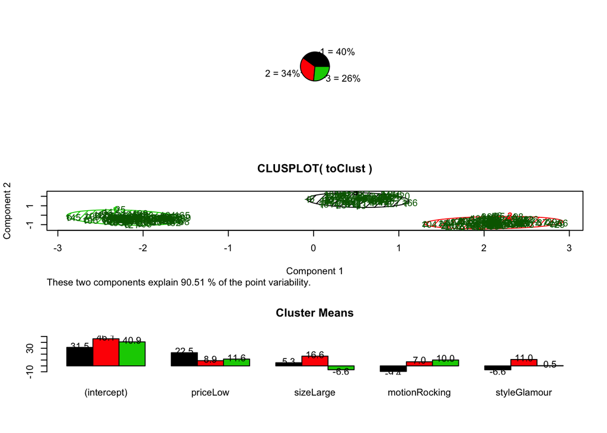

```r
#three segmentation is the best

km = kmeans(indiDataNew,3,iter.max = 100, nstart=20)

plotClust = function(km,toClust,discPlot=FALSE){
  nc = length(km$size)
  if(discPlot){par(mfrow=c(2,2))}
  else {par(mfrow=c(3,1))}
  percsize = paste(1:nc," = ",format(km$size/sum(km$size)*100,digits=2),"%",sep="")
  pie(km$size,labels=percsize,col=1:nc)

  clusplot(toClust, km$cluster, color=TRUE, shade=TRUE,
           labels=2, lines=0,col.clus=1:nc);

  if(discPlot){
    plotcluster(toClust, km$cluster,col=km$cluster);
  }
  rng = range(km$centers)
  dist = rng[2]-rng[1]
  locs = km$centers+.05*dist*ifelse(km$centers>0,1,-1)
  bm = barplot(km$centers,beside=TRUE,col=1:nc,main="Cluster Means",ylim=rng+dist*c(-.1,.1))
  text(bm,locs,formatC(km$centers,format="f",digits=1))
}

plotClust(km,indiDataNew)
```

```r
############### PART B ###############
```

- Results interpretation
  - Three clusters is the best choice.
  - Segment 1 prefer low price, large size, racing and bouncing,ideal product is profile 4.
  - Segment 2 prefer low price, large size, rocking and glamorous, ideal product is profile 16.
  - Segment 3 prefer low price, small size, rocking and no prefrence for style, ideal product is profile 14.

##### Part C A Prior Analysis:

- Conduct a priori segmentation using the variables gender and age in order to profile the attribute preferences based on these variables (use segment-level regressions)
- Test whether these a priori segmentation variables affect the part-utilities. What does this test tell you about these as segmentation schemes?
- If the differences are meaningful, profile the segment-level attribute preferences and identify the ideal product for the a priori segments.

```r
############### PART C ###############
#prior segmentation
segData = merge(conjointData,respondentData,on="ID",all=TRUE)
lm1 = summary(lm(ratings~price*age+size*age+motion*age+style*age,data=segData))
lm2 = summary(lm(ratings~price+size+motion+style,data=conjointData))
lm3 = summary(lm(ratings~price*gender+size*gender+motion*gender+style*gender,data=segData))
lm4 = summary(lm(ratings~price*gender+size*gender+motion*gender+style*gender+price*age+size*age+motion*age+style*age,data=segData))
#Interaction coefficients show that boys and girls have different prefrence,
#but the diffence is not significant between the two age groups

#only gender
maleData = segData[segData$gender=="0",]
femaleData = segData[segData$gender=="1",]
lm5 = summary(lm(ratings~price+size+motion+style,data=maleData)) #style significant
lm6 = summary(lm(ratings~price+size+motion+style,data=femaleData)) #both significant

#only age
twoData = segData[segData$age=="0",]
threefourData = segData[segData$age=="1",]
lm7 = summary(lm(ratings~price+size+motion+style,data=twoData)) #motion significant
lm8 = summary(lm(ratings~price+size+motion+style,data=threefourData)) #both not significant

#both gender and age
maletwoData = segData[segData$gender=="0"&segData$age=="0",]
femaletwoData = segData[segData$gender=="1"&segData$age=="0",]
femalethreefourData = segData[segData$gender=="1"&segData$age=="1",]
malethreefourData = segData[segData$gender=="0"&segData$age=="1",]
lm9 = summary(lm(ratings~price+size+motion+style,data=maletwoData)) #not significant
lm10 = summary(lm(ratings~price+size+motion+style,data=femaletwoData)) #both significant
lm11 = summary(lm(ratings~price+size+motion+style,data=femalethreefourData)) #both significant
lm12 = summary(lm(ratings~price+size+motion+style,data=malethreefourData)) #both significant
############### PART C ###############
```

##### Part D Market Simulation:

- Use disaggregate analysis with a first choice rule to forecast market shares. Using these market shares and the information about costs in the case, calculate profitability for each product in the product line as well as the overall profitability for the firm.
- Present at least 4 scenarios that try to identify the best possible product line strategy given considerations related to competitive response, cannibalization, profitability, and long-run performance.

```r
############### PART D ###############
#market simulation
ratingData = as.data.frame(matrix(NA,200,16))
colnames(ratingData) = c("profile1","profile2","profile3","profile4","profile5","profile6","profile7","profile8",
                       "profile9","profile10","profile11","profile12","profile13","profile14","profile15","profile16")
#fillout ranking data
for (id in 1:200){
  data = conjointData[conjointData$ID == id,]
  for (row in 1:16){
    ratingData[id,row] = data[row,3]
  }
}
ID = 1:200
ratingData = cbind(ID,ratingData)
ratingDataInt = as.data.frame(apply(ratingData,2,round))

#gender preference
test = respondentData
colnames(test) = c("id","age","gender")
test = merge(indiData,test,on="id",all=FALSE)
femaleTest = test[test$gender=="1",]
maleTest = test[test$gender=="0",]

ratingNew = merge(ratingDataInt,respondentData,on = "ID",all=FALSE)
femaleRating = ratingNew[ratingNew$gender == "1",]
maleRating = ratingNew[ratingNew$gender == "0",]
femaleRatingAvg = (colSums(femaleRating)/108)[2:17]
mean(femaleRatingAvg) #54.82465
```

```
## [1] 54.82465
```

```r
maleRatingAvg = (colSums(maleRating)/92)[2:17]
mean(maleRatingAvg) #45.60326
```

```
## [1] 45.60326
```

```r
#Girl Ideal Product:6,10,14,15
#Boy Ideal Product:2,6,10

#find max rating
simFCDecisions = function(scen,data,ascend=FALSE){
  test = data[,scen]
  Matrix = matrix(0,200,length(test))
  colnames(Matrix) = colnames(test)
  test$max = 0
  if(ascend){
    for (y in 1:200){
      test$max[y] = min(test[y,])
    }
  } else {
    for (y in 1:200){
      test$max[y] = max(test[y,])
    }
  }
  for (r in 1:200){
    for (c in 1:(length(test)-1)){
      if(test[r,c]==test[r,"max"]){
        Matrix[r,c] = 1
      }
    }
  }
  Matrix = as.data.frame(Matrix)
  Matrix
}

calcUnitShares = function(decisions){
  colSums(decisions)/sum(decisions)
}

simFCShares=function(scen,data,ascend=FALSE){
  decs = simFCDecisions(scen,data,ascend)
  calcUnitShares(decs)
}

#Plan A
simFCShares(c(3,7,15),ratingDataInt[,2:17])
```

```
##  profile3  profile7 profile15
## 0.3823529 0.1764706 0.4411765
```

```r
#revenue = (111.99-29)*4000*0.3823529 = 126925.9
#revenue = (111.99-41)*4000*0.4411765  = 125276.5
#cost = 20000*2+20000/3*2 = 53333.33
#profit = 126925.9+125276.5-53333.33 = 198869.1
simFCShares(c(4,8,16),ratingDataInt[,2:17])
```

```
##  profile4  profile8 profile16
## 0.3474178 0.2018779 0.4507042
```

```r
#revenue = (95.99-29)*4000*0.3474178 = 93094.07
#revenue = (95.99-41)*4000*0.4507042 = 99136.9
#cost = 20000*2 = 40000
#profit = 93094.07+99136.9-40000 = 152231
#totalprofit = 198869.1+152231*4 = 807793.1

#Plan B
simFCShares(c(5,7,13),ratingDataInt[,2:17]) #current
```

```
##  profile5  profile7 profile13
## 0.2186047 0.5534884 0.2279070
```

```r
simFCShares(c(7,11),ratingDataInt[,2:17]) #first year
```

```
##  profile7 profile11
##  0.436019  0.563981
```

```r
#revenue = (111.99-29)*4000*0.563981 = 187219.1
#cost = 20000+20000/3 = 26666.67
#profit = 187219.1-26666.67 = 160552.4
simFCShares(c(2,7),ratingDataInt[,2:17]) #second year
```

```
##  profile2  profile7
## 0.6568627 0.3431373
```

```r
#revenue = (95.99-21)*4000*0.6568627 = 197032.5
#cost = 20000+20000/3 = 26666.67
#profit = 197032.5-26666.67 = 170365.8
simFCShares(c(2,7,15),ratingDataInt[,2:17]) #third year
```

```
##   profile2   profile7  profile15
## 0.62376238 0.04455446 0.33168317
```

```r
#revenue = (95.99-21)*4000*0.62376238 = 187103.8
#revenue = (111.99-41)*4000*0.33168317 = 94184.75
#cost = 20000*2+20000/3 = 46666.67
#profit = 187103.8+94184.75-46666.67 = 234621.9
simFCShares(c(2,8,16),ratingDataInt[,2:17])
```

```
##  profile2  profile8 profile16
## 0.3287037 0.2638889 0.4074074
```

```r
#revenue = (95.99-21)*4000*0.3287037 = 98597.96
#revenue = (95.99-41)*4000*0.4074074 = 89613.33
#cost = 20000*2 = 40000
#profit = 98597.96+89613.33-40000 = 148211.3
#totalprofit = 160552.4+170365.8+234621.9+148211.3*2 = 861962.7

#Plan B (sensitivity analysis)
simFCShares(c(5,7,13),ratingDataInt[,2:17]) #current
```

```
##  profile5  profile7 profile13
## 0.2186047 0.5534884 0.2279070
```

```r
simFCShares(c(7,11),ratingDataInt[,2:17]) #first year
```

```
##  profile7 profile11
##  0.436019  0.563981
```

```r
#revenue = (111.99-29)*4000*0.563981 = 187219.1
#cost = 20000+20000/3 = 26666.67
#profit = 187219.1-26666.67 = 160552.4
simFCShares(c(2,7),ratingDataInt[,2:17]) #second year
```

```
##  profile2  profile7
## 0.6568627 0.3431373
```

```r
#revenue = (95.99-21)*4000*0.6568627 = 197032.5
#cost = 20000+20000/3 = 26666.67
#profit = 197032.5-26666.67 = 170365.8
simFCShares(c(2,8,15),ratingDataInt[,2:17]) #third year
```

```
##  profile2  profile8 profile15
## 0.3461538 0.4375000 0.2163462
```

```r
#revenue = (95.99-21)*4000*0.3461538 = 103832.3
#revenue = (111.99-41)*4000*0.2163462 = 61433.67
#cost = 20000*2+20000/3 = 46666.67
#profit = 103832.3+61433.67-46666.67 = 118599.3
simFCShares(c(2,8,16),ratingDataInt[,2:17]) #forth year
```

```
##  profile2  profile8 profile16
## 0.3287037 0.2638889 0.4074074
```

```r
#revenue = (95.99-21)*4000*0.3287037 = 98597.96
#revenue = (95.99-41)*4000*0.4074074  = 89613.33
#cost = 20000*2 = 40000
#profit = 98597.96+89613.33-40000 = 148211.3
#totalprofit = 160552.4+170365.8+118599.3+148211.3*2 = 745940.1
#total = 861962.7*0.6+745940.1*0.4 = 815553.7

#Plan C (competitor response)
simFCShares(c(5,7,13),ratingDataInt[,2:17]) #current
```

```
##  profile5  profile7 profile13
## 0.2186047 0.5534884 0.2279070
```

```r
simFCShares(c(3,7,15),ratingDataInt[,2:17]) #first year
```

```
##  profile3  profile7 profile15
## 0.3823529 0.1764706 0.4411765
```

```r
simFCShares(c(3,8,15),ratingDataInt[,2:17]) #second year
```

```
##    profile3    profile8   profile15
## 0.004950495 0.767326733 0.227722772
```

```r
#Plan D (cannibolization)
simFCShares(c(5,7,13),ratingDataInt[,2:17]) #current
```

```
##  profile5  profile7 profile13
## 0.2186047 0.5534884 0.2279070
```

```r
simFCShares(c(6,7),ratingDataInt[,2:17]) #first year
```

```
##  profile6  profile7
## 0.7178218 0.2821782
```

```r
simFCShares(c(6,6,10),ratingDataInt[,2:17]) #second year
```

```
##   profile6 profile6.1  profile10
##  0.2861953  0.2861953  0.4276094
```

```r
simFCShares(c(6,6,10),ratingDataInt[,2:17]) #third year
```

```
##   profile6 profile6.1  profile10
##  0.2861953  0.2861953  0.4276094
```

```r
#Plan E
simFCShares(c(5,7,13),ratingDataInt[,2:17]) #current
```

```
##  profile5  profile7 profile13
## 0.2186047 0.5534884 0.2279070
```

```r
simFCShares(c(7,11),ratingDataInt[,2:17]) #first year
```

```
##  profile7 profile11
##  0.436019  0.563981
```

```r
simFCShares(c(7,7,11),ratingDataInt[,2:17]) #second year
```

```
##   profile7 profile7.1  profile11
##  0.3036304  0.3036304  0.3927393
```

```r
simFCShares(c(6,7,11),ratingDataInt[,2:17]) #third year
```

```
##   profile6   profile7  profile11
## 0.65853659 0.08292683 0.25853659
```

```r
#create scenario
scens = list()
scens[[1]]=c(5,7,13)
scens[[2]]=c(7,11)
scens[[3]]=c(2,7)
scens[[4]]=c(2,7,15)
scens[[5]]=c(2,8,16)

scens2 = list()
scens2[[1]]=c(5,7,13)
scens2[[2]]=c(7,11)
scens2[[3]]=c(2,7)
scens2[[4]]=c(2,8,15)
scens2[[5]]=c(2,8,16)

scens3 = list()
scens3[[1]]=c(5,7,13)
scens3[[2]]=c(3,7,15)
scens3[[3]]=c(4,8,16)


simFCScenarios = function(scenarios,data,...){
  res = matrix(nrow=length(scenarios),ncol=length(data))
  for(i in 1:length(scenarios)){
    res[i, scenarios[[i]] ] = simFCShares(scenarios[[i]],data,...)
  }
  res = as.data.frame(res)
  names(res) = names(data)
  res
}

shareData1= simFCScenarios(scens,ratingData[,2:17])
shareDataCut1= shareData1[,c(2,5,7,8,11,13,15,16)]
shareData2= simFCScenarios(scens2,ratingData[,2:17])
shareDataCut2= shareData2[,c(2,5,7,8,11,13,15,16)]
shareData3= simFCScenarios(scens3,ratingData[,2:17])
shareDataCut3= shareData3[,c(3,4,5,7,8,13,15,16)]
############### PART D ###############
```